--- title : "RHomework" date : "2020-06-13" author : "VEC" ---

# RHomework1

Valentino Emil Chai

3/6/2020

## Libraries

```r
library(tidyr)
library(afex)
library(emmeans)
library(psych)
```

```r
library(ggplot2)
```

## Task 1: Importing

Using MY working directory

```r
afex.wide <- read.csv("D:/Users/valentinoman12/Documents/School/Psych/PL3261/R Homework/R homework/afex.wide.csv")
```

```r
head(afex.wide)
```

```
##   id   instruction AC_implausible AC_plausible DA_implausible DA_plausible
## 1  8 probabilistic           98.0         99.0           98.5         99.0
## 2  9     deductive           15.0         99.0           74.5         99.5
## 3 10 probabilistic           49.5         84.5           75.0         91.0
## 4 12     deductive           99.5         99.5          100.0         99.5
## 5 13     deductive           74.0         99.5           25.0         74.0
## 6 15     deductive            0.0          0.0            0.0          0.0
##   MP_implausible MP_plausible MT_implausible MT_plausible
## 1           74.0         99.5           73.5         89.5
## 2           99.0         99.0           49.5         24.0
## 3           81.5         99.0           55.0         99.0
## 4           99.5         99.5          100.0         99.5
## 5           65.0         99.0           74.5         49.5
## 6          100.0         99.5           49.5        100.0
```

```r
str(afex.wide)
```

```
## 'data.frame':    40 obs. of  10 variables:
##  $ id            : int  8 9 10 12 13 15 16 17 18 19 ...
##  $ instruction   : Factor w/ 2 levels "deductive","probabilistic": 2 1 2 1 1 1 2 2 1 1 ...
##  $ AC_implausible: num  98 15 49.5 99.5 74 0 84 14.5 49.5 99 ...
##  $ AC_plausible  : num  99 99 84.5 99.5 99.5 0 89.5 96.5 50 100 ...
##  $ DA_implausible: num  98.5 74.5 75 100 25 0 64.5 77 99.5 99.5 ...
##  $ DA_plausible  : num  99 99.5 91 99.5 74 0 85 98 99.5 99 ...
##  $ MP_implausible: num  74 99 81.5 99.5 65 100 84.5 39.5 99 99.5 ...
##  $ MP_plausible  : num  99.5 99 99 99.5 99 99.5 95 97.5 99.5 100 ...
##  $ MT_implausible: num  73.5 49.5 55 100 74.5 49.5 49 37.5 99.5 99.5 ...
##  $ MT_plausible  : num  89.5 24 99 99.5 49.5 100 64.5 98 99.5 100 ...
```

## Task 2: From Wide to Long

```r
afex.dat <- gather(afex.wide, key = "Condition", value = "Score", -instruction, -id)

head(afex.dat)
```

```
##   id   instruction      Condition Score
## 1  8 probabilistic AC_implausible  98.0
## 2  9     deductive AC_implausible  15.0
## 3 10 probabilistic AC_implausible  49.5
## 4 12     deductive AC_implausible  99.5
## 5 13     deductive AC_implausible  74.0
## 6 15     deductive AC_implausible   0.0
```

```r
str(afex.dat)
```

```
## 'data.frame':    320 obs. of  4 variables:
##  $ id         : int  8 9 10 12 13 15 16 17 18 19 ...
##  $ instruction: Factor w/ 2 levels "deductive","probabilistic": 2 1 2 1 1 1 2 2 1 1 ...
##  $ Condition  : chr  "AC_implausible" "AC_implausible" "AC_implausible" "AC_implausible" ...
##  $ Score      : num  98 15 49.5 99.5 74 0 84 14.5 49.5 99 ...
```

```r
afex.dat$plausibility <- ifelse(afex.dat$Condition == "AC_implausible"|afex.dat$Condition =="DA_implausible"|afex.dat$Condition == "MT_implausible"|afex.dat$Condition == "MP_implausible", "Implausible","Plausible")

afex.dat$inference <- ifelse(grepl("AC", afex.dat$Condition), "AC",
                             ifelse(grepl("DA", afex.dat$Condition), "DA",
                                    ifelse(grepl("MT", afex.dat$Condition), "MT", "MP")))

afex.dat$validity <- ifelse(afex.dat$inference == "AC"|afex.dat$inference == "DA", "invalid","valid")

headTail(afex.dat)
```

```
##      id   instruction      Condition Score plausibility inference validity
## 1     8 probabilistic AC_implausible    98  Implausible        AC  invalid
## 2     9     deductive AC_implausible    15  Implausible        AC  invalid
## 3    10 probabilistic AC_implausible  49.5  Implausible        AC  invalid
## 4    12     deductive AC_implausible  99.5  Implausible        AC  invalid
## ... ...          <NA>           <NA>   ...         <NA>      <NA>     <NA>
## 317  47 probabilistic   MT_plausible  99.5    Plausible        MT    valid
## 318  48     deductive   MT_plausible    50    Plausible        MT    valid
## 319  49 probabilistic   MT_plausible    95    Plausible        MT    valid
## 320  50     deductive   MT_plausible     0    Plausible        MT    valid
```

## Task 3: Plotting

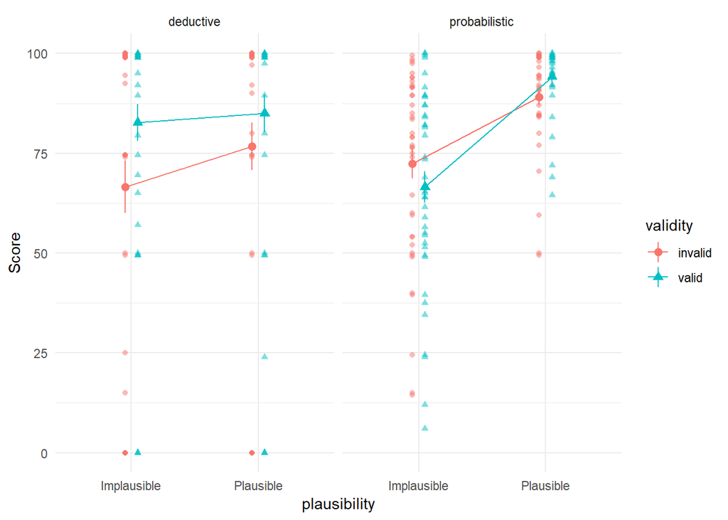

```r
afex.dat %>%
  ggplot(aes(x = plausibility, y = Score, col = validity, shape = validity, group = validity)) + geom_point(position = position_dodge(0.2), alpha = 0.5) + theme_minimal() + stat_summary(fun.data = mean_se, geom = "pointrange", position = position_dodge(0.2)) + stat_summary(fun.y = mean, geom = "line", position = position_dodge(0.2)) + facet_wrap(~instruction)
```

## Task 4: 2-way WS ANOVA

```r
twoway <- aov_car(Score ~ validity*plausibility + Error(id/validity*plausibility), data = afex.dat)
summary(twoway)
```

```
##
## Univariate Type III Repeated-Measures ANOVA Assuming Sphericity
##
##                        Sum Sq num Df Error SS den Df   F value    Pr(>F)
## (Intercept)           1002118      1    38832     39 1006.4579 < 2.2e-16
## validity                 1398      1    14473     39    3.7681   0.05949
## plausibility             8023      1    11408     39   27.4282  5.91e-06
## validity:plausibility      25      1     7954     39    0.1236   0.72709
##
## (Intercept)           ***
## validity              .
## plausibility          ***
## validity:plausibility
## ---
## Signif. codes:  0 '***' 0.001 '**' 0.01 '*' 0.05 '.' 0.1 ' ' 1
```

## Task 5: Reporting and Follow-up(s)

Q1:

There was a significant main effect of plausibility, F(1, 39) = 27.4, p < .001, and a marginally significant main effect of validity, F(1, 39) = 3.77, p = .059. There was no significant interaction between validity and plausibility, F(1, 39) = 0.12, p = .73

Q2:

No, posthoc comparisons are not necessary. Both validity and plausibility only have two levels each.

Q3:

No tests of simple effects are necessary as the interaction is not significant.

Q4:

We can conclude that participants’ performances on plausible problems was better than their performances on implausible problems. However, we cannot conclude that performances differed between valid and invalid problems. Neither can we conclude that the differences in performance between plausible and implausible or valid and invalid problems varied depending on problem validity or plausibility respectively.

## Task 6: 3-way

```r
threeway <- aov_car(Score ~ instruction + Error(id/validity*plausibility), data = afex.dat)
```

```
## Contrasts set to contr.sum for the following variables: instruction
```

```r
summary(threeway)
```

```
##
## Univariate Type III Repeated-Measures ANOVA Assuming Sphericity
##
##                                    Sum Sq num Df Error SS den Df  F value
## (Intercept)                       1002118      1    38521     38 988.5637
## instruction                           311      1    38521     38   0.3066
## validity                             1398      1    12894     38   4.1208
## instruction:validity                 1578      1    12894     38   4.6509
## plausibility                         8023      1     8908     38  34.2265
## instruction:plausibility             2500      1     8908     38  10.6666
## validity:plausibility                  25      1     7066     38   0.1355
## instruction:validity:plausibility     888      1     7066     38   4.7775
##                                      Pr(>F)
## (Intercept)                       < 2.2e-16 ***
## instruction                        0.583016
## validity                           0.049401 *
## instruction:validity               0.037429 *
## plausibility                      9.134e-07 ***
## instruction:plausibility           0.002315 **
## validity:plausibility              0.714800
## instruction:validity:plausibility  0.035066 *
## ---
## Signif. codes:  0 '***' 0.001 '**' 0.01 '*' 0.05 '.' 0.1 ' ' 1
```

## Task 7:

Q: The three-way interaction between instruction, validity, and plausibility will be examined further.

## Task 8: Simple effects good lord

Simple interaction at each level of plausibility (selected this factor due to literature on belief bias)

```r
joint_tests(threeway, by = "plausibility")
```

```
## plausibility = Implausible:
##  model term           df1   df2 F.ratio p.value
##  instruction            1 54.68   0.840 0.3635
##  validity               1 70.03   1.995 0.1622
##  instruction:validity   1 70.03   9.204 0.0034
##
## plausibility = Plausible:
##  model term           df1   df2 F.ratio p.value
##  instruction            1 54.68   3.665 0.0608
##  validity               1 70.03   3.425 0.0684
##  instruction:validity   1 70.03   0.187 0.6664
```

```r
m1 <-emmeans(threeway, pairwise ~ validity|instruction, by = "plausibility", adj = "bon")
m1
```

```
## $emmeans
## instruction = deductive, plausibility = Implausible:
##  validity emmean   SE df lower.CL upper.CL
##  invalid    66.6 4.71 97     57.2     75.9
##  valid      82.7 4.71 97     73.3     92.0
##
## instruction = probabilistic, plausibility = Implausible:
##  validity emmean   SE df lower.CL upper.CL
##  invalid    72.4 4.71 97     63.1     81.8
##  valid      66.6 4.71 97     57.2     75.9
##
## instruction = deductive, plausibility = Plausible:
##  validity emmean   SE df lower.CL upper.CL
##  invalid    76.7 4.71 97     67.4     86.1
##  valid      85.0 4.71 97     75.7     94.4
##
## instruction = probabilistic, plausibility = Plausible:
##  validity emmean   SE df lower.CL upper.CL
##  invalid    89.0 4.71 97     79.7     98.3
##  valid      94.1 4.71 97     84.8    103.5
##
## Warning: EMMs are biased unless design is perfectly balanced
## Confidence level used: 0.95
##
## $contrasts
## instruction = deductive, plausibility = Implausible:
##  contrast        estimate   SE df t.ratio p.value
##  invalid - valid   -16.11 5.12 70 -3.144  0.0024
##
## instruction = probabilistic, plausibility = Implausible:
##  contrast        estimate   SE df t.ratio p.value
##  invalid - valid     5.88 5.12 70  1.146  0.2555
##
## instruction = deductive, plausibility = Plausible:
##  contrast        estimate   SE df t.ratio p.value
##  invalid - valid    -8.28 5.12 70 -1.615  0.1109
##
## instruction = probabilistic, plausibility = Plausible:
##  contrast        estimate   SE df t.ratio p.value
##  invalid - valid    -5.14 5.12 70 -1.002  0.3196
```

## Task 9: Planned contrasts

```r
#Plausible vs. Implausible
means<-emmeans(threeway, specs =~ plausibility:validity:instruction)
c1 <- c(-1,1,-1,1,-1,1,-1,1)
list1 <- list("Plausible vs. Implausible" = c1)
contrast(means, list1)
```

```
##  contrast                  estimate   SE df t.ratio p.value
##  Plausible vs. Implausible     56.6 9.68 38 5.850   <.0001
```

```r
#Performance is better on plausible than implausible problems


#Valid plausible vs. everything else
c2 <- c(-1,-1,-1,3,-1,-1,-1,3)
list2 <- list("Valid plausible vs. everything else" = c2)
contrast(means, list2)
```

```
##  contrast                            estimate   SE  df t.ratio p.value
##  Valid plausible vs. everything else     83.5 17.4 107 4.789   <.0001
```

```r
#Performance is better on valid plausible problems than other types of problems


#Probabilistic plausible valid vs. everything else
c3 <- c(-1,-1,-1,-1,-1,-1,-1,7)
list3 <- list("Probabilistic plausible valid vs. everything else" = c3)
contrast(means, list3)
```

```
##  contrast                                          estimate   SE  df
##  Probabilistic plausible valid vs. everything else      120 31.8 132
##  t.ratio p.value
##  3.769   0.0002
```

```r
#Performance is better on probabilistic plausible valid problems than other types of problems
```

## Task 10: Bonus

### Hypo 1

```r
con1 <- c(0,-1,0,1,0,1,0,-1)
con2 <- c(-1,0,1,0,1,0,-1,0)
conlist <- list("Validity effect difference when plausible" = con1,
                "Validity effect difference when implausible" = con2)
contrast(means, conlist)
```

```
##  contrast                                    estimate   SE df t.ratio
##  Validity effect difference when plausible       3.14 7.25 70 0.433
##  Validity effect difference when implausible    21.99 7.25 70 3.034
##  p.value
##  0.6664
##  0.0034
```

Hypothesis 1 supported

### Hypo 2

```r
con3 <- c(1,-1,-1,1,0,0,0,0)
con4 <- c(0,0,0,0,1,-1,-1,1)
conlist2 <- list("Plausibility effect difference when deductive" = con3, "Plausibility effect difference when probabilistic" = con4)
contrast(means,conlist2)
```

```
##  contrast                                          estimate  SE df t.ratio
##  Plausibility effect difference when deductive        -7.84 6.1 38 -1.285
##  Plausibility effect difference when probabilistic    11.01 6.1 38  1.806
##  p.value
##  0.2065
##  0.0789
```

Hypothesis 2 supported, although the difference in the effect of plausibility was only marginally significantly higher for valid problems than invalid problems